# ProblemDescription

```
## here() starts at /Users/Martin/Documents/C.Development/C.B.GitHub/ProblemRenderPDF
```

# Problem

When creating a RMarkdown document with the following, standard `yaml` everything works out well and a pdf is produced.

```r
---
title: "Failed Test"
output:
  pdf_document: default
  html_document: default
---

This is going to work
```

If the text contains just one markdown markup like `#` for making a title:

```r
---
title: "Failed Test"
output:
  pdf_document: default
  html_document: default
---

# This is not going to work
```

the following error message is given without further compilation.

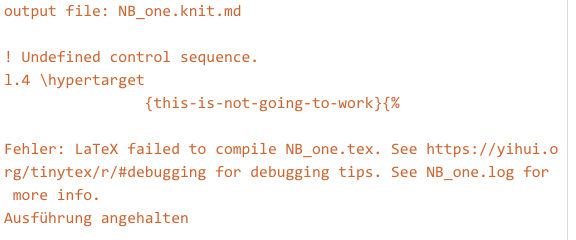

The error message may vary a bit but is often of the type `!undefined control sequence`.

The log file looks like

```python
This is pdfTeX, Version 3.14159265-2.6-1.40.21 (TeX Live 2020) (preloaded format=pdflatex 2020.12.10)  15 DEC 2020 18:42
entering extended mode
 restricted \write18 enabled.
 %&-line parsing enabled.
**NB_one.tex
(./NB_one.tex
LaTeX2e <2020-10-01> patch level 2
L3 programming layer <2020-12-07> xparse <2020-03-03> (/Users/Martin/Library/Ti
nyTeX/texmf-dist/tex/latex/base/minimal.cls
Document Class: minimal 2001/05/25 Standard LaTeX minimal class
)
(/Users/Martin/Library/TinyTeX/texmf-dist/tex/latex/l3backend/l3backend-pdftex.
def
File: l3backend-pdftex.def 2020-09-24 L3 backend support: PDF output (pdfTeX)
\l__kernel_color_stack_int=\count177
\l__pdf_internal_box=\box47
)
No file NB_one.aux.
\openout1 = `NB_one.aux'.

LaTeX Font Info:    Checking defaults for OML/cmm/m/it on input line 2.
LaTeX Font Info:    ... okay on input line 2.
LaTeX Font Info:    Checking defaults for OMS/cmsy/m/n on input line 2.
LaTeX Font Info:    ... okay on input line 2.
LaTeX Font Info:    Checking defaults for OT1/cmr/m/n on input line 2.
LaTeX Font Info:    ... okay on input line 2.
LaTeX Font Info:    Checking defaults for T1/cmr/m/n on input line 2.
LaTeX Font Info:    ... okay on input line 2.
LaTeX Font Info:    Checking defaults for TS1/cmr/m/n on input line 2.
LaTeX Font Info:    ... okay on input line 2.
LaTeX Font Info:    Checking defaults for OMX/cmex/m/n on input line 2.
LaTeX Font Info:    ... okay on input line 2.
LaTeX Font Info:    Checking defaults for U/cmr/m/n on input line 2.
LaTeX Font Info:    ... okay on input line 2.
! Undefined control sequence.
l.4 \hypertarget
                {this-is-not-going-to-work}{%
Here is how much of TeX's memory you used:
 192 strings out of 481331
 5031 string characters out of 5917010
 264796 words of memory out of 5000000
 17145 multiletter control sequences out of 15000+600000
 403430 words of font info for 27 fonts, out of 8000000 for 9000
 14 hyphenation exceptions out of 8191
 38i,0n,46p,127b,38s stack positions out of 5000i,500n,10000p,200000b,80000s

!  ==> Fatal error occurred, no output PDF file produced!
```

I have done all proposed changes I could find:

- reinstall `tinytex` with all the miracles of `tinytex::install_tinytex()` and closing and opening *RStudio*
- deleted *MacTex* with *Latexit* and *TexShop*
- re-installed it again
  - updated **ALL** *latex*-packages
- I have made a *tex.file* with adding `keep_tex=true` out of the *Rmd.file* and tried to compile this in *TexShop*.
- I have made the same with with an *md.file* and tried to compile via pandoc with `pandoc text.md -s -o text.pdf` without any succes. It led to the same error message as from *RStudio*.
- I upgraded *pandoc* from something like *2.5* to now *2.11.2* without any success.
- After recognizing that the upgrade of *pandoc* initially did not lead the system to find the right version, I found out that there was a *Haskell pandoc* version, which I deleted. The new version could then be found via terminal `pandoc --version` and in *RStudio* with `rmarkdown::pandoc_version()`.
- I followed all the recommendations Yihui gave
- I posted a question in *RCommunity* without any reply
- All relevant *R-packages* were updated

At latest here I was thinking about the *pandoc-template* as a possible source of the problem. And I found this [talk.macpoweruser](https://talk.macpowerusers.com/t/workflow-automatically-convert-markdown-to-pdf-pandoc-latex-hazel/15506/11)

and this [StackExchange](https://tex.stackexchange.com/questions/257418/error-tightlist-converting-md-file-into-pdf-using-pandoc)

I downloaded [this](https://raw.githubusercontent.com/jgm/pandoc-templates/master/default.latex) new *template* , stored in the directory where *.Rmd* was with the name *mytemp.tex* and changed my *yaml* to:

```r
---
output:
  pdf_document:
    template: mytemp.tex
  html_document:
    df_print: paged
---
```

**That worked!**